# Risk Factor Analysis

## Outcome Variable

**Outcome Variable:** ever_stunted

## Predictor Variables

**Intervention Variable:** hhwealth_quart

**Adjustment Set:**

unadjusted

## Stratifying Variables

The analysis was stratified on these variable(s):

- agecat
- studyid

The following strata were considered:

- agecat: 12 months, studyid: ki0047075b-MAL-ED
- agecat: 12 months, studyid: ki1000108-CMC-V-BCS-2002
- agecat: 12 months, studyid: ki1000108-IRC
- agecat: 12 months, studyid: ki1017093b-PROVIDE
- agecat: 12 months, studyid: ki1066203-TanzaniaChild2
- agecat: 12 months, studyid: ki1113344-GMS-Nepal
- agecat: 12 months, studyid: ki1114097-CONTENT
- agecat: 12 months, studyid: ki1135781-COHORTS
- agecat: 12 months, studyid: ki1148112-LCNI-5
- agecat: 18 months, studyid: ki0047075b-MAL-ED
- agecat: 18 months, studyid: ki1000108-CMC-V-BCS-2002
- agecat: 18 months, studyid: ki1000108-IRC
- agecat: 18 months, studyid: ki1017093b-PROVIDE
- agecat: 18 months, studyid: ki1066203-TanzaniaChild2
- agecat: 18 months, studyid: ki1113344-GMS-Nepal
- agecat: 18 months, studyid: ki1114097-CONTENT
- agecat: 18 months, studyid: ki1135781-COHORTS
- agecat: 18 months, studyid: ki1148112-LCNI-5
- agecat: 24 months, studyid: ki0047075b-MAL-ED
- agecat: 24 months, studyid: ki1000108-CMC-V-BCS-2002
- agecat: 24 months, studyid: ki1000108-IRC
- agecat: 24 months, studyid: ki1017093b-PROVIDE
- agecat: 24 months, studyid: ki1066203-TanzaniaChild2
- agecat: 24 months, studyid: ki1113344-GMS-Nepal
- agecat: 24 months, studyid: ki1114097-CONTENT
- agecat: 24 months, studyid: ki1135781-COHORTS
- agecat: 24 months, studyid: ki1148112-LCNI-5
- agecat: 3 months, studyid: ki0047075b-MAL-ED
- agecat: 3 months, studyid: ki1000108-CMC-V-BCS-2002
- agecat: 3 months, studyid: ki1000108-IRC
- agecat: 3 months, studyid: ki1017093b-PROVIDE
- agecat: 3 months, studyid: ki1066203-TanzaniaChild2
- agecat: 3 months, studyid: ki1113344-GMS-Nepal
- agecat: 3 months, studyid: ki1114097-CONTENT
- agecat: 3 months, studyid: ki1135781-COHORTS
- agecat: 6 months, studyid: ki0047075b-MAL-ED
- agecat: 6 months, studyid: ki1000108-CMC-V-BCS-2002
- agecat: 6 months, studyid: ki1000108-IRC
- agecat: 6 months, studyid: ki1017093b-PROVIDE
- agecat: 6 months, studyid: ki1066203-TanzaniaChild2
- agecat: 6 months, studyid: ki1113344-GMS-Nepal
- agecat: 6 months, studyid: ki1114097-CONTENT
- agecat: 6 months, studyid: ki1135781-COHORTS
- agecat: 6 months, studyid: ki1148112-LCNI-5

## Methods Detail

We’re interested in the causal parameters $E[Y_a]$ for all values of $a \in \mathcal{A}$. These parameters represent the mean outcome if, possibly contrary to fact, we intervened to set all units to have $A=a$. Under the randomization and positivity assumptions, these are identified by the statistical parameters $\psi_a=E_W[E_{Y|A,W}(Y|A=a,W)]$. In addition, we’re interested in the mean of $Y$, $E[Y]$ under no intervention (the observed mean). We will estimate these parameters by using SuperLearner to fit the relevant likelihood factors – $E_{Y|A,W}(Y|A=a,W)$ and $p(A=a|W)$, and then updating our likelihood fit using a joint TMLE.

For unadjusted analyses ($W=\{\}$), initial likelihoods were estimated using Lrnr_glm to estimate the simple $E(Y|A)$ and Lrnr_mean to estimate $p(A)$. For adjusted analyses, a small library containing Lrnr_glmnet, Lrnr_xgboost, and Lrnr_mean was used.

Having estimated these parameters, we will then use the delta method to estimate relative risks and attributable risks relative to a prespecified baseline level of $A$.

# Results Detail

## Results Plots

[figure not shown]

[figure not shown]

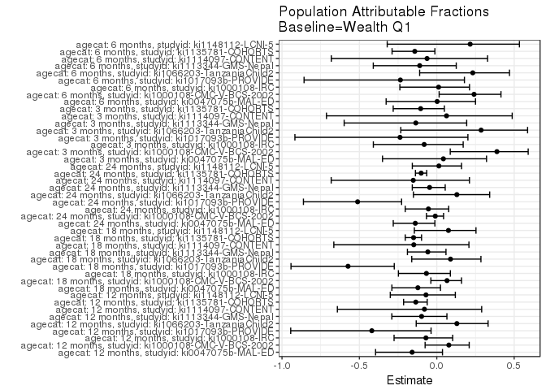

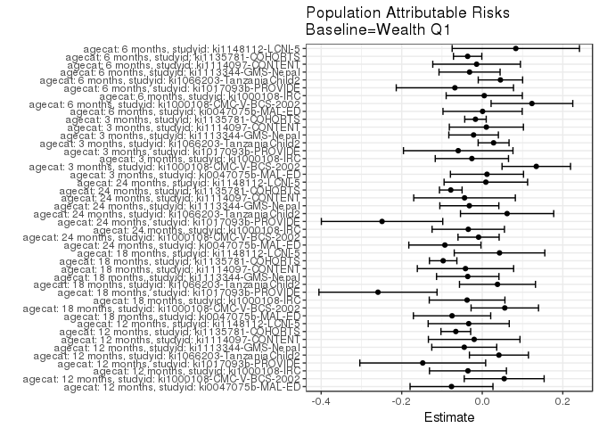

## Data Summary

| agecat | studyid | A | n | nA | nAY0 | nAY1 |
| --- | --- | --- | --- | --- | --- | --- |
| 3 months | ki0047075b-MAL-ED | Wealth Q1 | 363 | 91 | 67 | 24 |
| 3 months | ki0047075b-MAL-ED | Wealth Q2 | 363 | 88 | 67 | 21 |
| 3 months | ki0047075b-MAL-ED | Wealth Q3 | 363 | 92 | 60 | 32 |
| 3 months | ki0047075b-MAL-ED | Wealth Q4 | 363 | 92 | 69 | 23 |
| 3 months | ki1000108-CMC-V-BCS-2002 | Wealth Q1 | 362 | 90 | 71 | 19 |
| 3 months | ki1000108-CMC-V-BCS-2002 | Wealth Q2 | 362 | 91 | 60 | 31 |
| 3 months | ki1000108-CMC-V-BCS-2002 | Wealth Q3 | 362 | 89 | 59 | 30 |
| 3 months | ki1000108-CMC-V-BCS-2002 | Wealth Q4 | 362 | 92 | 47 | 45 |
| 3 months | ki1000108-IRC | Wealth Q1 | 410 | 105 | 69 | 36 |
| 3 months | ki1000108-IRC | Wealth Q2 | 410 | 102 | 66 | 36 |
| 3 months | ki1000108-IRC | Wealth Q3 | 410 | 103 | 74 | 29 |
| 3 months | ki1000108-IRC | Wealth Q4 | 410 | 100 | 71 | 29 |
| 3 months | ki1017093b-PROVIDE | Wealth Q1 | 175 | 45 | 31 | 14 |
| 3 months | ki1017093b-PROVIDE | Wealth Q2 | 175 | 40 | 31 | 9 |
| 3 months | ki1017093b-PROVIDE | Wealth Q3 | 175 | 42 | 29 | 13 |
| 3 months | ki1017093b-PROVIDE | Wealth Q4 | 175 | 48 | 40 | 8 |
| 3 months | ki1066203-TanzaniaChild2 | Wealth Q1 | 600 | 171 | 159 | 12 |
| 3 months | ki1066203-TanzaniaChild2 | Wealth Q2 | 600 | 114 | 102 | 12 |
| 3 months | ki1066203-TanzaniaChild2 | Wealth Q3 | 600 | 171 | 155 | 16 |
| 3 months | ki1066203-TanzaniaChild2 | Wealth Q4 | 600 | 144 | 125 | 19 |
| 3 months | ki1113344-GMS-Nepal | Wealth Q1 | 593 | 150 | 123 | 27 |
| 3 months | ki1113344-GMS-Nepal | Wealth Q2 | 593 | 148 | 125 | 23 |
| 3 months | ki1113344-GMS-Nepal | Wealth Q3 | 593 | 149 | 126 | 23 |
| 3 months | ki1113344-GMS-Nepal | Wealth Q4 | 593 | 146 | 125 | 21 |
| 3 months | ki1114097-CONTENT | Wealth Q1 | 215 | 59 | 50 | 9 |
| 3 months | ki1114097-CONTENT | Wealth Q2 | 215 | 52 | 43 | 9 |
| 3 months | ki1114097-CONTENT | Wealth Q3 | 215 | 52 | 45 | 7 |
| 3 months | ki1114097-CONTENT | Wealth Q4 | 215 | 52 | 42 | 10 |
| 3 months | ki1135781-COHORTS | Wealth Q1 | 3537 | 794 | 652 | 142 |
| 3 months | ki1135781-COHORTS | Wealth Q2 | 3537 | 628 | 505 | 123 |

[output cut: 150 more lines]

## Results Table

### Parameter: TSM

| agecat | studyid | intervention_level | baseline_level | estimate | ci_lower | ci_upper |
| --- | --- | --- | --- | --- | --- | --- |
| 3 months | ki0047075b-MAL-ED | Wealth Q1 | NA | 0.2637363 | 0.1730737 | 0.3543988 |
| 3 months | ki0047075b-MAL-ED | Wealth Q2 | NA | 0.2386364 | 0.1494558 | 0.3278169 |
| 3 months | ki0047075b-MAL-ED | Wealth Q3 | NA | 0.3478261 | 0.2503684 | 0.4452837 |
| 3 months | ki0047075b-MAL-ED | Wealth Q4 | NA | 0.2500000 | 0.1613959 | 0.3386041 |
| 3 months | ki1000108-CMC-V-BCS-2002 | Wealth Q1 | NA | 0.2111111 | 0.1266822 | 0.2955400 |
| 3 months | ki1000108-CMC-V-BCS-2002 | Wealth Q2 | NA | 0.3406593 | 0.2431507 | 0.4381680 |
| 3 months | ki1000108-CMC-V-BCS-2002 | Wealth Q3 | NA | 0.3370787 | 0.2387341 | 0.4354232 |
| 3 months | ki1000108-CMC-V-BCS-2002 | Wealth Q4 | NA | 0.4891304 | 0.3868430 | 0.5914179 |
| 3 months | ki1000108-IRC | Wealth Q1 | NA | 0.3428571 | 0.2519558 | 0.4337585 |
| 3 months | ki1000108-IRC | Wealth Q2 | NA | 0.3529412 | 0.2600870 | 0.4457953 |
| 3 months | ki1000108-IRC | Wealth Q3 | NA | 0.2815534 | 0.1945898 | 0.3685170 |
| 3 months | ki1000108-IRC | Wealth Q4 | NA | 0.2900000 | 0.2009556 | 0.3790444 |
| 3 months | ki1017093b-PROVIDE | Wealth Q1 | NA | 0.3111111 | 0.1754615 | 0.4467607 |
| 3 months | ki1017093b-PROVIDE | Wealth Q2 | NA | 0.2250000 | 0.0952209 | 0.3547791 |
| 3 months | ki1017093b-PROVIDE | Wealth Q3 | NA | 0.3095238 | 0.1693105 | 0.4497371 |
| 3 months | ki1017093b-PROVIDE | Wealth Q4 | NA | 0.1666667 | 0.0609349 | 0.2723985 |
| 3 months | ki1066203-TanzaniaChild2 | Wealth Q1 | NA | 0.0701754 | 0.0318572 | 0.1084937 |
| 3 months | ki1066203-TanzaniaChild2 | Wealth Q2 | NA | 0.1052632 | 0.0488807 | 0.1616456 |
| 3 months | ki1066203-TanzaniaChild2 | Wealth Q3 | NA | 0.0935673 | 0.0498813 | 0.1372532 |
| 3 months | ki1066203-TanzaniaChild2 | Wealth Q4 | NA | 0.1319444 | 0.0766224 | 0.1872665 |
| 3 months | ki1113344-GMS-Nepal | Wealth Q1 | NA | 0.1800000 | 0.1184664 | 0.2415336 |
| 3 months | ki1113344-GMS-Nepal | Wealth Q2 | NA | 0.1554054 | 0.0969882 | 0.2138226 |
| 3 months | ki1113344-GMS-Nepal | Wealth Q3 | NA | 0.1543624 | 0.0963014 | 0.2124234 |
| 3 months | ki1113344-GMS-Nepal | Wealth Q4 | NA | 0.1438356 | 0.0868651 | 0.2008061 |
| 3 months | ki1114097-CONTENT | Wealth Q1 | NA | 0.1525424 | 0.0605846 | 0.2445002 |
| 3 months | ki1114097-CONTENT | Wealth Q2 | NA | 0.1730769 | 0.0700120 | 0.2761419 |
| 3 months | ki1114097-CONTENT | Wealth Q3 | NA | 0.1346154 | 0.0416309 | 0.2275999 |
| 3 months | ki1114097-CONTENT | Wealth Q4 | NA | 0.1923077 | 0.0849384 | 0.2996770 |
| 3 months | ki1135781-COHORTS | Wealth Q1 | NA | 0.1788413 | 0.1521821 | 0.2055005 |
| 3 months | ki1135781-COHORTS | Wealth Q2 | NA | 0.1958599 | 0.1648165 | 0.2269032 |

[output cut: 146 more lines]

### Parameter: E(Y)

| agecat | studyid | intervention_level | baseline_level | estimate | ci_lower | ci_upper |
| --- | --- | --- | --- | --- | --- | --- |
| 3 months | ki0047075b-MAL-ED | NA | NA | 0.2754821 | 0.2710457 | 0.2799185 |
| 3 months | ki1000108-CMC-V-BCS-2002 | NA | NA | 0.3453039 | 0.3351147 | 0.3554930 |
| 3 months | ki1000108-IRC | NA | NA | 0.3170732 | 0.3140300 | 0.3201164 |
| 3 months | ki1017093b-PROVIDE | NA | NA | 0.2514286 | 0.2422017 | 0.2606555 |
| 3 months | ki1066203-TanzaniaChild2 | NA | NA | 0.0983333 | 0.0965201 | 0.1001466 |
| 3 months | ki1113344-GMS-Nepal | NA | NA | 0.1585160 | 0.1574456 | 0.1595864 |
| 3 months | ki1114097-CONTENT | NA | NA | 0.1627907 | 0.1599261 | 0.1656553 |
| 3 months | ki1135781-COHORTS | NA | NA | 0.1620017 | 0.1611825 | 0.1628209 |
| 6 months | ki0047075b-MAL-ED | NA | NA | 0.3453039 | 0.3416846 | 0.3489232 |
| 6 months | ki1000108-CMC-V-BCS-2002 | NA | NA | 0.5122616 | 0.5015225 | 0.5230007 |
| 6 months | ki1000108-IRC | NA | NA | 0.4240196 | 0.4198628 | 0.4281765 |
| 6 months | ki1017093b-PROVIDE | NA | NA | 0.2891566 | 0.2806413 | 0.2976719 |
| 6 months | ki1066203-TanzaniaChild2 | NA | NA | 0.1942446 | 0.1914090 | 0.1970802 |
| 6 months | ki1113344-GMS-Nepal | NA | NA | 0.2857143 | 0.2838136 | 0.2876149 |
| 6 months | ki1114097-CONTENT | NA | NA | 0.2232558 | 0.2208855 | 0.2256261 |
| 6 months | ki1135781-COHORTS | NA | NA | 0.2550153 | 0.2537589 | 0.2562718 |
| 6 months | ki1148112-LCNI-5 | NA | NA | 0.3863636 | 0.3717523 | 0.4009749 |
| 12 months | ki0047075b-MAL-ED | NA | NA | 0.4792244 | 0.4739764 | 0.4844724 |
| 12 months | ki1000108-CMC-V-BCS-2002 | NA | NA | 0.6989247 | 0.6931997 | 0.7046497 |
| 12 months | ki1000108-IRC | NA | NA | 0.5073529 | 0.5022060 | 0.5124999 |
| 12 months | ki1017093b-PROVIDE | NA | NA | 0.3522013 | 0.3361744 | 0.3682282 |
| 12 months | ki1066203-TanzaniaChild2 | NA | NA | 0.3191919 | 0.3165437 | 0.3218401 |
| 12 months | ki1113344-GMS-Nepal | NA | NA | 0.4553265 | 0.4530054 | 0.4576475 |
| 12 months | ki1114097-CONTENT | NA | NA | 0.2511628 | 0.2492154 | 0.2531102 |
| 12 months | ki1135781-COHORTS | NA | NA | 0.4843322 | 0.4826229 | 0.4860416 |
| 12 months | ki1148112-LCNI-5 | NA | NA | 0.4821429 | 0.4785830 | 0.4857027 |
| 18 months | ki0047075b-MAL-ED | NA | NA | 0.6138889 | 0.6074123 | 0.6203655 |
| 18 months | ki1000108-CMC-V-BCS-2002 | NA | NA | 0.8471850 | 0.8429357 | 0.8514343 |
| 18 months | ki1000108-IRC | NA | NA | 0.5623472 | 0.5572701 | 0.5674243 |
| 18 months | ki1017093b-PROVIDE | NA | NA | 0.4516129 | 0.4275009 | 0.4757249 |
| 18 months | ki1066203-TanzaniaChild2 | NA | NA | 0.4261838 | 0.4215686 | 0.4307991 |
| 18 months | ki1113344-GMS-Nepal | NA | NA | 0.6236934 | 0.6216021 | 0.6257847 |
| 18 months | ki1114097-CONTENT | NA | NA | 0.2803738 | 0.2761872 | 0.2845604 |
| 18 months | ki1135781-COHORTS | NA | NA | 0.6474045 | 0.6447053 | 0.6501038 |
| 18 months | ki1148112-LCNI-5 | NA | NA | 0.5692308 | 0.5655993 | 0.5728623 |
| 24 months | ki0047075b-MAL-ED | NA | NA | 0.6685552 | 0.6598961 | 0.6772144 |
| 24 months | ki1000108-CMC-V-BCS-2002 | NA | NA | 0.9249330 | 0.9238081 | 0.9260579 |
| 24 months | ki1000108-IRC | NA | NA | 0.6414634 | 0.6347684 | 0.6481585 |
| 24 months | ki1017093b-PROVIDE | NA | NA | 0.4864865 | 0.4623964 | 0.5105766 |
| 24 months | ki1066203-TanzaniaChild2 | NA | NA | 0.4760000 | 0.4699160 | 0.4820840 |
| 24 months | ki1113344-GMS-Nepal | NA | NA | 0.6901408 | 0.6875504 | 0.6927312 |
| 24 months | ki1114097-CONTENT | NA | NA | 0.2893401 | 0.2844108 | 0.2942694 |
| 24 months | ki1135781-COHORTS | NA | NA | 0.7743539 | 0.7717720 | 0.7769358 |
| 24 months | ki1148112-LCNI-5 | NA | NA | 0.6552707 | 0.6512964 | 0.6592449 |

### Parameter: RR

| agecat | studyid | intervention_level | baseline_level | estimate | ci_lower | ci_upper |
| --- | --- | --- | --- | --- | --- | --- |
| 3 months | ki0047075b-MAL-ED | Wealth Q2 | Wealth Q1 | 0.9048295 | 0.5445589 | 1.5034490 |
| 3 months | ki0047075b-MAL-ED | Wealth Q3 | Wealth Q1 | 1.3188406 | 0.8464260 | 2.0549232 |
| 3 months | ki0047075b-MAL-ED | Wealth Q4 | Wealth Q1 | 0.9479167 | 0.5785484 | 1.5531043 |
| 3 months | ki1000108-CMC-V-BCS-2002 | Wealth Q2 | Wealth Q1 | 1.6136495 | 0.9867822 | 2.6387432 |
| 3 months | ki1000108-CMC-V-BCS-2002 | Wealth Q3 | Wealth Q1 | 1.5966884 | 0.9732581 | 2.6194631 |
| 3 months | ki1000108-CMC-V-BCS-2002 | Wealth Q4 | Wealth Q1 | 2.3169336 | 1.4754214 | 3.6384056 |
| 3 months | ki1000108-IRC | Wealth Q2 | Wealth Q1 | 1.0294118 | 0.7085603 | 1.4955517 |
| 3 months | ki1000108-IRC | Wealth Q3 | Wealth Q1 | 0.8211974 | 0.5465948 | 1.2337570 |
| 3 months | ki1000108-IRC | Wealth Q4 | Wealth Q1 | 0.8458333 | 0.5637702 | 1.2690172 |
| 3 months | ki1017093b-PROVIDE | Wealth Q2 | Wealth Q1 | 0.7232143 | 0.3509535 | 1.4903367 |
| 3 months | ki1017093b-PROVIDE | Wealth Q3 | Wealth Q1 | 0.9948980 | 0.5305414 | 1.8656826 |
| 3 months | ki1017093b-PROVIDE | Wealth Q4 | Wealth Q1 | 0.5357143 | 0.2480971 | 1.1567638 |
| 3 months | ki1066203-TanzaniaChild2 | Wealth Q2 | Wealth Q1 | 1.5000000 | 0.6980778 | 3.2231367 |
| 3 months | ki1066203-TanzaniaChild2 | Wealth Q3 | Wealth Q1 | 1.3333333 | 0.6500218 | 2.7349508 |
| 3 months | ki1066203-TanzaniaChild2 | Wealth Q4 | Wealth Q1 | 1.8802083 | 0.9445382 | 3.7427639 |
| 3 months | ki1113344-GMS-Nepal | Wealth Q2 | Wealth Q1 | 0.8633634 | 0.5194317 | 1.4350229 |
| 3 months | ki1113344-GMS-Nepal | Wealth Q3 | Wealth Q1 | 0.8575690 | 0.5158570 | 1.4256366 |
| 3 months | ki1113344-GMS-Nepal | Wealth Q4 | Wealth Q1 | 0.7990868 | 0.4735534 | 1.3484006 |
| 3 months | ki1114097-CONTENT | Wealth Q2 | Wealth Q1 | 1.1346154 | 0.4862351 | 2.6475918 |
| 3 months | ki1114097-CONTENT | Wealth Q3 | Wealth Q1 | 0.8824786 | 0.3528094 | 2.2073350 |
| 3 months | ki1114097-CONTENT | Wealth Q4 | Wealth Q1 | 1.2606838 | 0.5543221 | 2.8671482 |
| 3 months | ki1135781-COHORTS | Wealth Q2 | Wealth Q1 | 1.0951601 | 0.8810138 | 1.3613587 |
| 3 months | ki1135781-COHORTS | Wealth Q3 | Wealth Q1 | 0.9113299 | 0.7454052 | 1.1141888 |
| 3 months | ki1135781-COHORTS | Wealth Q4 | Wealth Q1 | 0.7118493 | 0.5720298 | 0.8858446 |
| 6 months | ki0047075b-MAL-ED | Wealth Q2 | Wealth Q1 | 0.9237537 | 0.6077741 | 1.4040099 |
| 6 months | ki0047075b-MAL-ED | Wealth Q3 | Wealth Q1 | 1.1676017 | 0.7992141 | 1.7057929 |
| 6 months | ki0047075b-MAL-ED | Wealth Q4 | Wealth Q1 | 0.9151473 | 0.6041663 | 1.3861987 |
| 6 months | ki1000108-CMC-V-BCS-2002 | Wealth Q2 | Wealth Q1 | 1.3136646 | 0.9466622 | 1.8229466 |
| 6 months | ki1000108-CMC-V-BCS-2002 | Wealth Q3 | Wealth Q1 | 1.2000000 | 0.8534095 | 1.6873493 |
| 6 months | ki1000108-CMC-V-BCS-2002 | Wealth Q4 | Wealth Q1 | 1.7323308 | 1.2900566 | 2.3262313 |

[output cut: 102 more lines]

### Parameter: PAR

| agecat | studyid | intervention_level | baseline_level | estimate | ci_lower | ci_upper |
| --- | --- | --- | --- | --- | --- | --- |
| 3 months | ki0047075b-MAL-ED | Wealth Q1 | NA | 0.0117458 | -0.0790252 | 0.1025169 |
| 3 months | ki1000108-CMC-V-BCS-2002 | Wealth Q1 | NA | 0.1341928 | 0.0491513 | 0.2192342 |
| 3 months | ki1000108-IRC | Wealth Q1 | NA | -0.0257840 | -0.1167362 | 0.0651683 |
| 3 months | ki1017093b-PROVIDE | Wealth Q1 | NA | -0.0596825 | -0.1956456 | 0.0762805 |
| 3 months | ki1066203-TanzaniaChild2 | Wealth Q1 | NA | 0.0281579 | -0.0102032 | 0.0665190 |
| 3 months | ki1113344-GMS-Nepal | Wealth Q1 | NA | -0.0214840 | -0.0830269 | 0.0400589 |
| 3 months | ki1114097-CONTENT | Wealth Q1 | NA | 0.0102483 | -0.0817541 | 0.1022508 |
| 3 months | ki1135781-COHORTS | Wealth Q1 | NA | -0.0168396 | -0.0435114 | 0.0098321 |
| 6 months | ki0047075b-MAL-ED | Wealth Q1 | NA | 0.0008594 | -0.0975159 | 0.0992347 |
| 6 months | ki1000108-CMC-V-BCS-2002 | Wealth Q1 | NA | 0.1233727 | 0.0219488 | 0.2247966 |
| 6 months | ki1000108-IRC | Wealth Q1 | NA | 0.0049720 | -0.0896099 | 0.0995539 |
| 6 months | ki1017093b-PROVIDE | Wealth Q1 | NA | -0.0679862 | -0.2135850 | 0.0776126 |
| 6 months | ki1066203-TanzaniaChild2 | Wealth Q1 | NA | 0.0451763 | -0.0099605 | 0.1003130 |
| 6 months | ki1113344-GMS-Nepal | Wealth Q1 | NA | -0.0315271 | -0.1073695 | 0.0443154 |
| 6 months | ki1114097-CONTENT | Wealth Q1 | NA | -0.0140323 | -0.1228641 | 0.0947995 |
| 6 months | ki1135781-COHORTS | Wealth Q1 | NA | -0.0362620 | -0.0714361 | -0.0010878 |
| 6 months | ki1148112-LCNI-5 | Wealth Q1 | NA | 0.0833333 | -0.0747389 | 0.2414056 |
| 12 months | ki0047075b-MAL-ED | Wealth Q1 | NA | -0.0763312 | -0.1792671 | 0.0266047 |
| 12 months | ki1000108-CMC-V-BCS-2002 | Wealth Q1 | NA | 0.0544803 | -0.0447130 | 0.1536736 |
| 12 months | ki1000108-IRC | Wealth Q1 | NA | -0.0355042 | -0.1310444 | 0.0600360 |
| 12 months | ki1017093b-PROVIDE | Wealth Q1 | NA | -0.1477987 | -0.3040611 | 0.0084637 |
| 12 months | ki1066203-TanzaniaChild2 | Wealth Q1 | NA | 0.0414141 | -0.0318639 | 0.1146922 |
| 12 months | ki1113344-GMS-Nepal | Wealth Q1 | NA | -0.0446735 | -0.1253303 | 0.0359832 |
| 12 months | ki1114097-CONTENT | Wealth Q1 | NA | -0.0200236 | -0.1337446 | 0.0936973 |
| 12 months | ki1135781-COHORTS | Wealth Q1 | NA | -0.0656678 | -0.1025672 | -0.0287684 |
| 12 months | ki1148112-LCNI-5 | Wealth Q1 | NA | -0.0336466 | -0.1343319 | 0.0670386 |
| 18 months | ki0047075b-MAL-ED | Wealth Q1 | NA | -0.0750000 | -0.1709962 | 0.0209962 |
| 18 months | ki1000108-CMC-V-BCS-2002 | Wealth Q1 | NA | 0.0559762 | -0.0277521 | 0.1397044 |
| 18 months | ki1000108-IRC | Wealth Q1 | NA | -0.0376528 | -0.1316091 | 0.0563034 |
| 18 months | ki1017093b-PROVIDE | Wealth Q1 | NA | -0.2589134 | -0.4055718 | -0.1122551 |
| 18 months | ki1066203-TanzaniaChild2 | Wealth Q1 | NA | 0.0378343 | -0.0565323 | 0.1322009 |
| 18 months | ki1113344-GMS-Nepal | Wealth Q1 | NA | -0.0360288 | -0.1135109 | 0.0414532 |
| 18 months | ki1114097-CONTENT | Wealth Q1 | NA | -0.0416601 | -0.1612405 | 0.0779204 |
| 18 months | ki1135781-COHORTS | Wealth Q1 | NA | -0.0970750 | -0.1311379 | -0.0630121 |
| 18 months | ki1148112-LCNI-5 | Wealth Q1 | NA | 0.0429150 | -0.0695726 | 0.1554026 |
| 24 months | ki0047075b-MAL-ED | Wealth Q1 | NA | -0.0928084 | -0.1824118 | -0.0032050 |
| 24 months | ki1000108-CMC-V-BCS-2002 | Wealth Q1 | NA | -0.0091330 | -0.0602022 | 0.0419363 |
| 24 months | ki1000108-IRC | Wealth Q1 | NA | -0.0347271 | -0.1245882 | 0.0551340 |
| 24 months | ki1017093b-PROVIDE | Wealth Q1 | NA | -0.2488076 | -0.3995418 | -0.0980735 |
| 24 months | ki1066203-TanzaniaChild2 | Wealth Q1 | NA | 0.0617143 | -0.0540735 | 0.1775020 |
| 24 months | ki1113344-GMS-Nepal | Wealth Q1 | NA | -0.0320814 | -0.1053478 | 0.0411851 |
| 24 months | ki1114097-CONTENT | Wealth Q1 | NA | -0.0439932 | -0.1701417 | 0.0821552 |
| 24 months | ki1135781-COHORTS | Wealth Q1 | NA | -0.0781583 | -0.1062609 | -0.0500557 |
| 24 months | ki1148112-LCNI-5 | Wealth Q1 | NA | 0.0089292 | -0.0947766 | 0.1126350 |

### Parameter: PAF

| agecat | studyid | intervention_level | baseline_level | estimate | ci_lower | ci_upper |
| --- | --- | --- | --- | --- | --- | --- |
| 3 months | ki0047075b-MAL-ED | Wealth Q1 | NA | 0.0426374 | -0.3506234 | 0.3213925 |
| 3 months | ki1000108-CMC-V-BCS-2002 | Wealth Q1 | NA | 0.3886222 | 0.0870068 | 0.5905963 |
| 3 months | ki1000108-IRC | Wealth Q1 | NA | -0.0813187 | -0.4098507 | 0.1706568 |
| 3 months | ki1017093b-PROVIDE | Wealth Q1 | NA | -0.2373737 | -0.9165936 | 0.2011380 |
| 3 months | ki1066203-TanzaniaChild2 | Wealth Q1 | NA | 0.2863515 | -0.2324219 | 0.5867533 |
| 3 months | ki1113344-GMS-Nepal | Wealth Q1 | NA | -0.1355319 | -0.5984287 | 0.1933123 |
| 3 months | ki1114097-CONTENT | Wealth Q1 | NA | 0.0629540 | -0.7126956 | 0.4873256 |
| 3 months | ki1135781-COHORTS | Wealth Q1 | NA | -0.1039471 | -0.2815162 | 0.0490176 |
| 6 months | ki0047075b-MAL-ED | Wealth Q1 | NA | 0.0024889 | -0.3272547 | 0.2503109 |
| 6 months | ki1000108-CMC-V-BCS-2002 | Wealth Q1 | NA | 0.2408392 | 0.0152402 | 0.4147557 |
| 6 months | ki1000108-IRC | Wealth Q1 | NA | 0.0117258 | -0.2385070 | 0.2114007 |
| 6 months | ki1017093b-PROVIDE | Wealth Q1 | NA | -0.2351190 | -0.8574604 | 0.1787071 |
| 6 months | ki1066203-TanzaniaChild2 | Wealth Q1 | NA | 0.2325742 | -0.1106674 | 0.4697401 |
| 6 months | ki1113344-GMS-Nepal | Wealth Q1 | NA | -0.1103448 | -0.4102355 | 0.1257732 |
| 6 months | ki1114097-CONTENT | Wealth Q1 | NA | -0.0628531 | -0.6813873 | 0.3281401 |
| 6 months | ki1135781-COHORTS | Wealth Q1 | NA | -0.1421952 | -0.2888285 | -0.0122448 |
| 6 months | ki1148112-LCNI-5 | Wealth Q1 | NA | 0.2156863 | -0.3202670 | 0.5340730 |
| 12 months | ki0047075b-MAL-ED | Wealth Q1 | NA | -0.1592807 | -0.3953805 | 0.0368708 |
| 12 months | ki1000108-CMC-V-BCS-2002 | Wealth Q1 | NA | 0.0779487 | -0.0754378 | 0.2094581 |
| 12 months | ki1000108-IRC | Wealth Q1 | NA | -0.0699793 | -0.2759250 | 0.1027249 |
| 12 months | ki1017093b-PROVIDE | Wealth Q1 | NA | -0.4196429 | -0.9437027 | -0.0368797 |
| 12 months | ki1066203-TanzaniaChild2 | Wealth Q1 | NA | 0.1297468 | -0.1329083 | 0.3315076 |
| 12 months | ki1113344-GMS-Nepal | Wealth Q1 | NA | -0.0981132 | -0.2903592 | 0.0654907 |
| 12 months | ki1114097-CONTENT | Wealth Q1 | NA | -0.0797238 | -0.6422402 | 0.2901139 |
| 12 months | ki1135781-COHORTS | Wealth Q1 | NA | -0.1355842 | -0.2144094 | -0.0618754 |
| 12 months | ki1148112-LCNI-5 | Wealth Q1 | NA | -0.0697856 | -0.3004131 | 0.1199403 |
| 18 months | ki0047075b-MAL-ED | Wealth Q1 | NA | -0.1221719 | -0.2900713 | 0.0238758 |
| 18 months | ki1000108-CMC-V-BCS-2002 | Wealth Q1 | NA | 0.0660732 | -0.0381586 | 0.1598400 |
| 18 months | ki1000108-IRC | Wealth Q1 | NA | -0.0669565 | -0.2478669 | 0.0877262 |
| 18 months | ki1017093b-PROVIDE | Wealth Q1 | NA | -0.5733083 | -0.9418943 | -0.2746826 |
| 18 months | ki1066203-TanzaniaChild2 | Wealth Q1 | NA | 0.0887747 | -0.1618105 | 0.2853124 |
| 18 months | ki1113344-GMS-Nepal | Wealth Q1 | NA | -0.0577669 | -0.1895934 | 0.0594510 |
| 18 months | ki1114097-CONTENT | Wealth Q1 | NA | -0.1485876 | -0.6651821 | 0.2077423 |
| 18 months | ki1135781-COHORTS | Wealth Q1 | NA | -0.1499449 | -0.2038374 | -0.0984650 |
| 18 months | ki1148112-LCNI-5 | Wealth Q1 | NA | 0.0753912 | -0.1449096 | 0.2533022 |
| 24 months | ki0047075b-MAL-ED | Wealth Q1 | NA | -0.1388193 | -0.2812590 | -0.0122149 |
| 24 months | ki1000108-CMC-V-BCS-2002 | Wealth Q1 | NA | -0.0098742 | -0.0666257 | 0.0438578 |
| 24 months | ki1000108-IRC | Wealth Q1 | NA | -0.0541372 | -0.2040090 | 0.0770789 |
| 24 months | ki1017093b-PROVIDE | Wealth Q1 | NA | -0.5114379 | -0.8615239 | -0.2271906 |
| 24 months | ki1066203-TanzaniaChild2 | Wealth Q1 | NA | 0.1296519 | -0.1508861 | 0.3418064 |
| 24 months | ki1113344-GMS-Nepal | Wealth Q1 | NA | -0.0464853 | -0.1582255 | 0.0544748 |
| 24 months | ki1114097-CONTENT | Wealth Q1 | NA | -0.1520468 | -0.6821622 | 0.2110084 |
| 24 months | ki1135781-COHORTS | Wealth Q1 | NA | -0.1009335 | -0.1378636 | -0.0652021 |
| 24 months | ki1148112-LCNI-5 | Wealth Q1 | NA | 0.0136267 | -0.1580376 | 0.1598440 |